# Uganda Performance Indicators

Francisco Rios Casas

November 22, 2019

## 1. Introduction

This document highlights the results for Performance Indicators in Uganda. Data for indicators all came from the latest available Progress Update and Disbursement Request forms (PUDRs) indicated below:

| File | Start of Reporting Period | End of Reporting Period |
| --- | --- | --- |
| LFA reviewed UGA-M-MoFPED Progress Update Report Jan-Jun 2019 17 Sept2019.xlsx | 2019-01-01 | 2019-06-30 |
| LFA verified UGA-M-TASO PU PE 30 June 2019 12 Sept 19.xlsx | 2019-01-01 | 2019-06-30 |
| LFA reviewed UGA-H-MoFPED Progress Update Report Jan-Jun 2019 17 09 19 (2).xlsx | 2019-01-01 | 2019-06-30 |
| LFA verified UGA-C-TASO PU PE 30 June 2019 12 Sept 19.xlsx | 2019-01-01 | 2019-06-30 |
| LFA reviewed UGA-T-MoFPED Progress Update Report for Jan-Jun 2019 17 09 19.xlsx | 2019-01-01 | 2019-06-30 |

## 2. Grant Results based on most recent PUDRs

The “Achievement Ratio” is calculated in the PUDR to understand how close to the original target the Outcome Indicator result is. A value of 1.0 or greater means that the Indicator’s goal has been met or exceeded.

### Malaria Grants

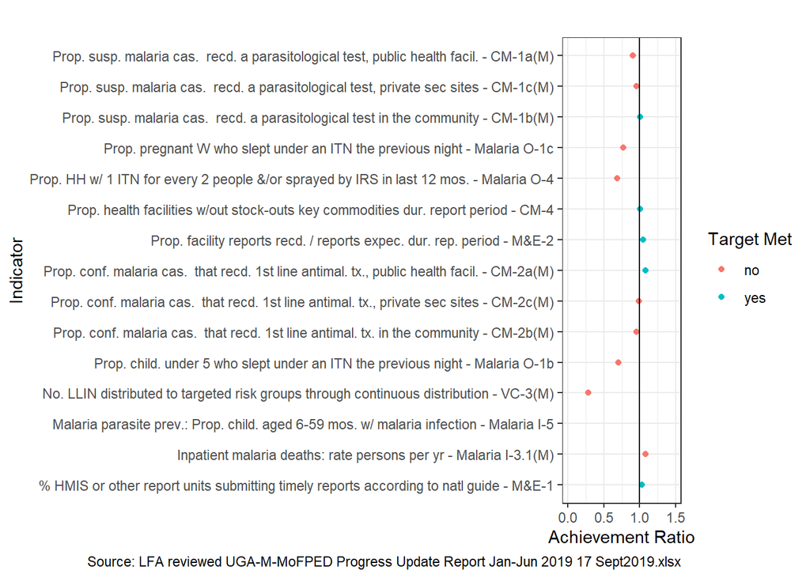

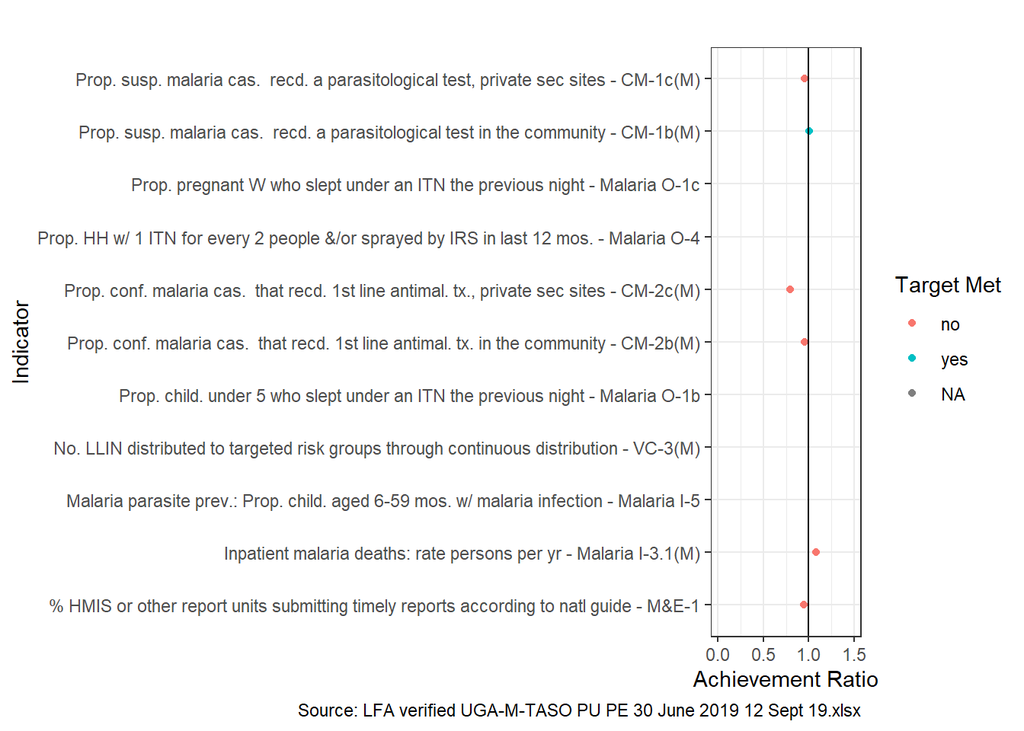

**The majority of indicators in the UGA-M-TASO grant are close to meeting their targets. The lowest-achieving indicators in the grant are related to antimalarial treatment in private sector sites and the timely reporting of HMIS-reporting sites.**

### HIV Grants

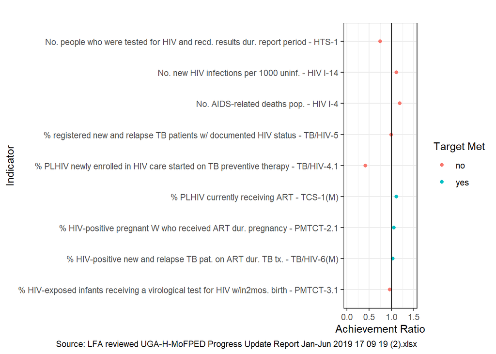

### Combined TB/HIV Grant

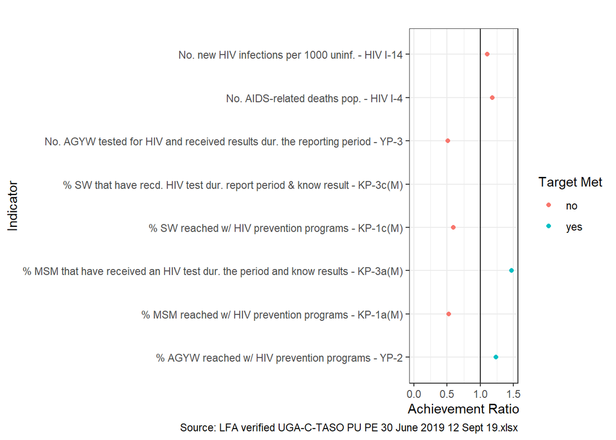

**There are mixed results relating to key populations in the UGA-C-TASO grant. While testing for MSM and prevention programs for AGYW have been reaching their targets, indicators for prevention programs for Sex Workers (SWs) and MSM have been far below target.**

### TB Grant

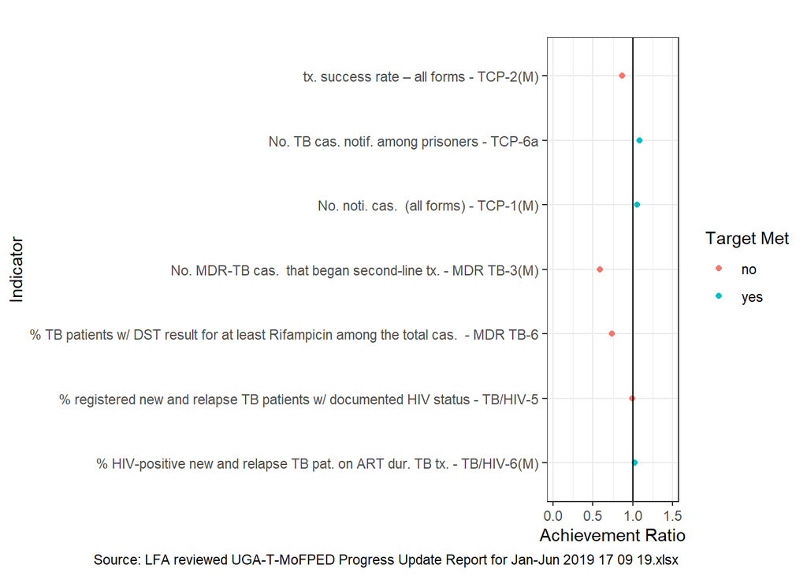

**Most of the indicators reported for the UGA-T-MoFPED grant are close to or exceeding their targets. Treatment for MDR-TB and Rifampicin drug-susceptibility testing were the furthest from their goals.**